# 11处理时间序列数据和检验自相关

LJJ

2020/3/28

The purpose of this in-class lab11 is to use R to practice estimating time series regression models and to test for **serial correlation**. The lab should be completed in your group. To get credit, upload your .R script to the appropriate place on Canvas.

## 11.1 For starters

First, install the `pdfetch`, `zoo`, and `dynlm` packages. `pdfetch` stands for “Public Data Fetch” and is a slick way of downloading statistics on stock prices, GDP, inflation, unemployment, etc. `zoo` and `dynlm` are packages useful for working with time series data.

Open up a new R script (named `ICL11_XYZ.R`, where `XYZ` are your initials) and add the usual “preamble” to the top:

```r
# Add names of group members HERE
library(tidyverse)
library(wooldridge)
library(broom)
library(car)
library(pdfetch)
library(zoo)
library(dynlm)
library(magrittr)
```

### 11.2 Load the data

We’re going to use data on **US macroeconomic indicators**. The `wooldridge` data set is called `intdef`.

```r
df <- as_tibble(intdef)
df %>% DT::datatable()
```

|  | year | i3 | inf | rec | out | def | i3_1 | inf_1 | def_1 | ci3 | cinf | cdef | y77 |
| --- | --- | --- | --- | --- | --- | --- | --- | --- | --- | --- | --- | --- | --- |
| 1 | 1948 | 1.03999996185303 | 8.10000038146973 | 16.2000007629395 | 11.6000003814697 | -4.60000038146973 |  |  |  |  |  |  | 0 |
| 2 | 1949 | 1.10000002384186 | -1.20000004768372 | 14.5 | 14.3000001907349 | -0.199999809265137 | 1.03999996185303 | 8.10000038146973 | -4.60000038146973 | 0.0600000619888306 | -9.30000019073486 | 4.40000057220459 | 0 |
| 3 | 1950 | 1.22000002861023 | 1.29999995231628 | 14.3999996185303 | 15.6000003814697 | 1.20000076293945 | 1.10000002384186 | -1.20000004768372 | -0.199999809265137 | 0.120000004768372 | 2.5 | 1.40000057220459 | 0 |
| 4 | 1951 | 1.54999995231628 | 7.90000009536743 | 16.1000003814697 | 14.1999998092651 | -1.90000057220459 | 1.22000002861023 | 1.29999995231628 | 1.20000076293945 | 0.329999923706055 | 6.60000038146973 | -3.10000133514404 | 0 |
| 5 | 1952 | 1.76999998092651 | 1.89999997615814 | 19 | 19.3999996185303 | 0.399999618530273 | 1.54999995231628 | 7.90000009536743 | -1.90000057220459 | 0.220000028610229 | -6 | 2.30000019073486 | 0 |
| 6 | 1953 | 1.92999994754791 | 0.800000011920929 | 18.7000007629395 | 20.3999996185303 | 1.69999885559082 | 1.76999998092651 | 1.89999997615814 | 0.399999618530273 | 0.159999966621399 | -1.09999990463257 | 1.29999923706055 | 0 |
| 7 | 1954 | 0.949999988079071 | 0.699999988079071 | 18.5 | 18.7999992370605 | 0.299999237060547 | 1.92999994754791 | 0.800000011920929 | 1.69999885559082 | -0.979999959468842 | -0.100000023841858 | -1.39999961853027 | 0 |
| 8 | 1955 | 1.75 | -0.400000005960464 | 16.5 | 17.2999992370605 | 0.799999237060547 | 0.949999988079071 | 0.699999988079071 | 0.299999237060547 | 0.800000011920929 | -1.10000002384186 | 0.5 | 0 |
| 9 | 1956 | 2.66000008583069 | 1.5 | 17.5 | 16.5 | -1 | 1.75 | -0.400000005960464 | 0.799999237060547 | 0.910000085830688 | 1.89999997615814 | -1.79999923706055 | 0 |
| 10 | 1957 | 3.26999998092651 | 3.29999995231628 | 17.7000007629395 | 17 | -0.700000762939453 | 2.66000008583069 | 1.5 | -1 | 0.609999895095825 | 1.79999995231628 | 0.299999237060547 | 0 |

[output cut: 46 more lines]

### 11.3 Declare `df` as time series data

```r
df.ts <- zoo(df, order.by=df$year)
df.ts
```

```
##      year    i3  inf  rec  out        def  i3_1 inf_1      def_1         ci3
## 1948 1948  1.04  8.1 16.2 11.6 -4.6000004    NA    NA         NA          NA
## 1949 1949  1.10 -1.2 14.5 14.3 -0.1999998  1.04   8.1 -4.6000004  0.06000006
## 1950 1950  1.22  1.3 14.4 15.6  1.2000008  1.10  -1.2 -0.1999998  0.12000000
## 1951 1951  1.55  7.9 16.1 14.2 -1.9000006  1.22   1.3  1.2000008  0.32999992
## 1952 1952  1.77  1.9 19.0 19.4  0.3999996  1.55   7.9 -1.9000006  0.22000003
## 1953 1953  1.93  0.8 18.7 20.4  1.6999989  1.77   1.9  0.3999996  0.15999997
## 1954 1954  0.95  0.7 18.5 18.8  0.2999992  1.93   0.8  1.6999989 -0.97999996
## 1955 1955  1.75 -0.4 16.5 17.3  0.7999992  0.95   0.7  0.2999992  0.80000001
## 1956 1956  2.66  1.5 17.5 16.5 -1.0000000  1.75  -0.4  0.7999992  0.91000009
## 1957 1957  3.27  3.3 17.7 17.0 -0.7000008  2.66   1.5 -1.0000000  0.60999990
## 1958 1958  1.84  2.8 17.3 17.9  0.6000004  3.27   3.3 -0.7000008 -1.42999995
## 1959 1959  3.41  0.7 16.2 18.8  2.5999985  1.84   2.8  0.6000004  1.57000005
## 1960 1960  2.93  1.7 17.8 17.8  0.0000000  3.41   0.7  2.5999985 -0.48000002
## 1961 1961  2.38  1.0 17.8 18.4  0.6000004  2.93   1.7  0.0000000 -0.54999995
```

[output cut: 99 more lines]

or:

```r
df %>% ts(frequency = 1,start = c(1948))
```

```
## Time Series:
## Start = 1948
## End = 2003
## Frequency = 1
##      year    i3  inf  rec  out        def  i3_1 inf_1      def_1         ci3
## 1948 1948  1.04  8.1 16.2 11.6 -4.6000004    NA    NA         NA          NA
## 1949 1949  1.10 -1.2 14.5 14.3 -0.1999998  1.04   8.1 -4.6000004  0.06000006
## 1950 1950  1.22  1.3 14.4 15.6  1.2000008  1.10  -1.2 -0.1999998  0.12000000
## 1951 1951  1.55  7.9 16.1 14.2 -1.9000006  1.22   1.3  1.2000008  0.32999992
## 1952 1952  1.77  1.9 19.0 19.4  0.3999996  1.55   7.9 -1.9000006  0.22000003
## 1953 1953  1.93  0.8 18.7 20.4  1.6999989  1.77   1.9  0.3999996  0.15999997
## 1954 1954  0.95  0.7 18.5 18.8  0.2999992  1.93   0.8  1.6999989 -0.97999996
## 1955 1955  1.75 -0.4 16.5 17.3  0.7999992  0.95   0.7  0.2999992  0.80000001
## 1956 1956  2.66  1.5 17.5 16.5 -1.0000000  1.75  -0.4  0.7999992  0.91000009
## 1957 1957  3.27  3.3 17.7 17.0 -0.7000008  2.66   1.5 -1.0000000  0.60999990
```

[output cut: 103 more lines]

Now it will be easy to include lags of various variables into our regression models.

## 11.2 Plot time series data

Let’s have a look at the inflation rate for the US over the period 1948–2003:

```r
df.ts %>% class()
```

```
## [1] "zoo"
```

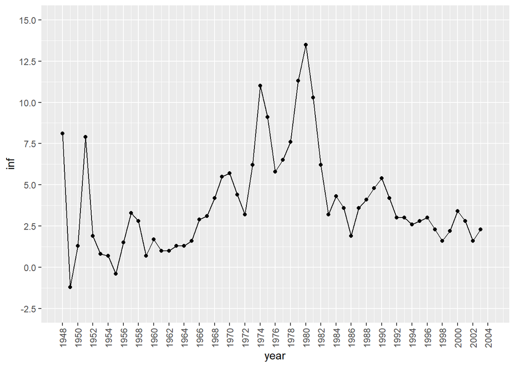

```r
ggplot(df.ts, aes(year, inf)) +
  geom_line() +
  geom_point() +
  scale_x_continuous(limits = c(1948,2004),breaks = seq(1948,2004,2)) +
  scale_y_continuous(limits = c(-2.5,15),breaks = seq(-2.5,15,2.5)) +
  theme(axis.text.x = element_text(angle = 90,hjust = 0.5,vjust = 0.5))
```

## 11.3 Determinants of the interest rate

Now let’s estimate the following regression model:

$$i3_{t} = \beta_0 + \beta_1 inf_t + \beta_2 inf_{t-1} + \beta_3 inf_{t-2} + \beta_4 def_{t} + u_t$$

where $i3$ is the **3-month Treasury Bill interest rate**, $inf$ is the inflation rate (as measured by the CPI), and $def$ is the budget deficit as a percentage of GDP.

The interface and internals of **dynlm** are very similar to **lm**, but currently dynlm offers **three advantages** over the direct use of lm:

1. extended formula processing
2. preservation of time series attributes
3. instrumental variables regression (via two-stage least squares)

```r
est <- dynlm(i3 ~ inf + L(inf,1) + L(inf,2) + def, data=df.ts)
est %>% summary()
```

```
##
## Time series regression with "zoo" data:
## Start = 1950, End = 2003
##
## Call:
## dynlm(formula = i3 ~ inf + L(inf, 1) + L(inf, 2) + def, data = df.ts)
##
## Residuals:
##     Min      1Q  Median      3Q     Max
## -3.6223 -1.3623  0.0655  1.2051  3.4422
##
## Coefficients:
##             Estimate Std. Error t value Pr(>|t|)
## (Intercept)   1.6478     0.4519   3.647 0.000643 ***
## inf           0.4966     0.1317   3.770 0.000439 ***
## L(inf, 1)     0.1419     0.1562   0.908 0.368107
## L(inf, 2)     0.1350     0.1222   1.104 0.274941
## def           0.2216     0.1591   1.393 0.169826
## ---
## Signif. codes:  0 '***' 0.001 '**' 0.01 '*' 0.05 '.' 0.1 ' ' 1
##
## Residual standard error: 1.778 on 49 degrees of freedom
## Multiple R-squared:  0.633,  Adjusted R-squared:  0.603
## F-statistic: 21.12 on 4 and 49 DF,  p-value: 3.576e-10
```

1. Are any of these variables significant determinants of the interest rate? If so, which ones?

## 11.4 Testing for Serial Correlation

Now let’s test for serial correlation in our model. Serial correlation is defined as

$$u_t = \rho u_{t-1}$$

with $\vert\rho\vert>0$.

We want to test

$$H_0: \rho = 0$$

To do so, we need to run a regression of residuals (from `est`) on lagged residuals and look at the $t$-stat.

```r
resids <- resid(est)
est.resid <- dynlm(resids ~ L(resids))
tidy(est.resid)
```

```
## # A tibble: 2 x 5
##   term        estimate std.error statistic       p.value
##   <chr>          <dbl>     <dbl>     <dbl>         <dbl>
## 1 (Intercept) 0.000656     0.168   0.00390 0.997
## 2 L(resids)   0.712        0.102   7.01    0.00000000521
```

2. What is the outcome of the hypothesis test?

### 11.4.1 When the $x$’s aren’t strictly exogenous

When $x$ is correlated with lags of $u$, we need to modify the above test to include our $x$’s from our original regression:

```r
est.resid. <- dynlm(resids ~ L(resids) + inf + L(inf,1) + L(inf,2) + def, data = df.ts)
est.resid. %>% summary()
```

```
##
## Time series regression with "zoo" data:
## Start = 1951, End = 2003
##
## Call:
## dynlm(formula = resids ~ L(resids) + inf + L(inf, 1) + L(inf,
##     2) + def, data = df.ts)
##
## Residuals:
##     Min      1Q  Median      3Q     Max
## -2.4923 -0.4932  0.0490  0.8664  3.2582
##
## Coefficients:
##             Estimate Std. Error t value Pr(>|t|)
## (Intercept)  0.02948    0.31653   0.093    0.926
## L(resids)    0.72121    0.10379   6.949 9.77e-09 ***
## inf         -0.01343    0.09333  -0.144    0.886
## L(inf, 1)   -0.08945    0.12312  -0.727    0.471
## L(inf, 2)    0.14435    0.10001   1.443    0.156
## def         -0.10479    0.11312  -0.926    0.359
## ---
## Signif. codes:  0 '***' 0.001 '**' 0.01 '*' 0.05 '.' 0.1 ' ' 1
##
## Residual standard error: 1.243 on 47 degrees of freedom
## Multiple R-squared:  0.5148, Adjusted R-squared:  0.4631
## F-statistic: 9.972 on 5 and 47 DF,  p-value: 1.51e-06
```

3. What do you conclude about serial correlation in this more general case?